# Analyzing Individual BGG Users

Phil Henrickson

2022-01-01

# **Redfame’s** BoardGameGeek Collection

This notebook contains a set of analyses for the selected user’s boardgamegeek collection. The bulk of the analysis is focused on building a user-specific predictive model to predict the games that Redfame is likely to own. This enables to ask questions like, based on the games the user currently owns, what games are a good fit for their collection? What upcoming games are they likely to purchase?

This analysis is based on data from BoardGameGeek that was last updated on **2021-12-20.**

# 1 Collection Overview

We can look at a basic description of the number of games that the user owns, has rated, has previously owned, etc.

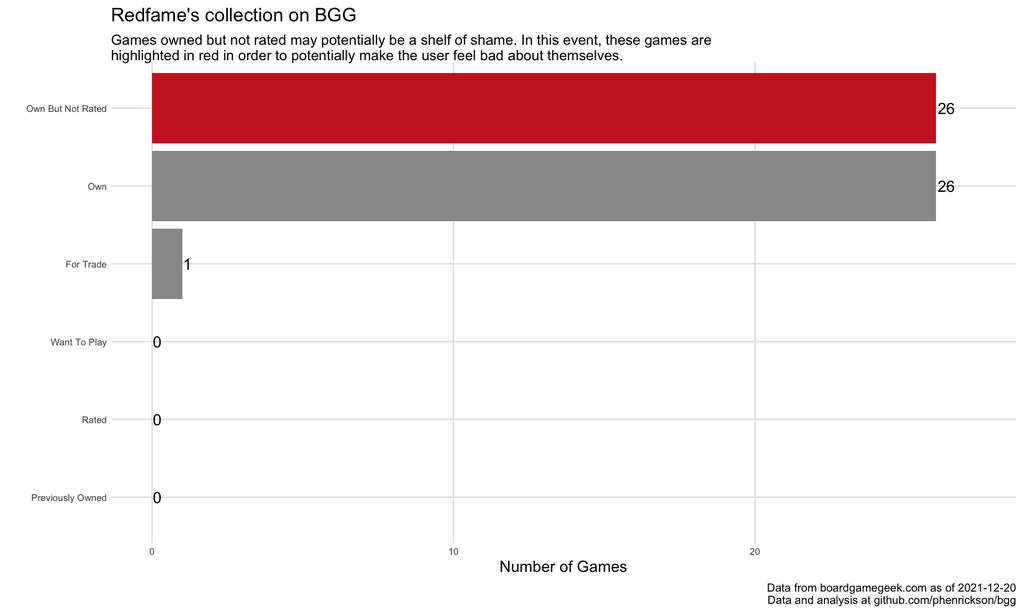

What years has the user owned/rated games from? While we can’t see when a user added or removed a game from their collection, we can look at their collection by the years in which their games were published.

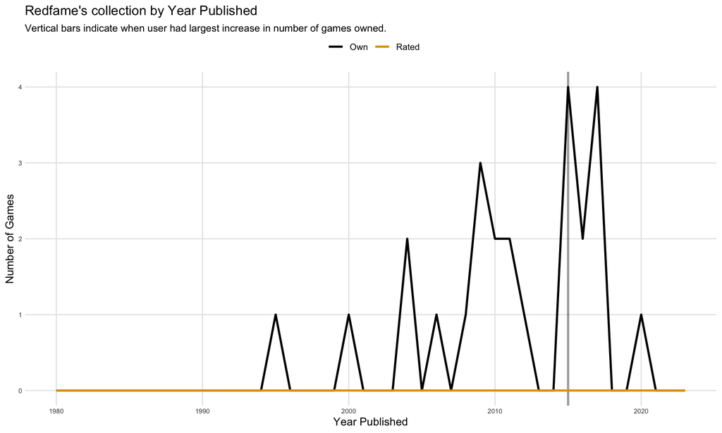

## 1.1 What types of games does Redfame own?

We can look at the most frequent types of categories, mechanics, designers, and artists that appear in a user’s collection.

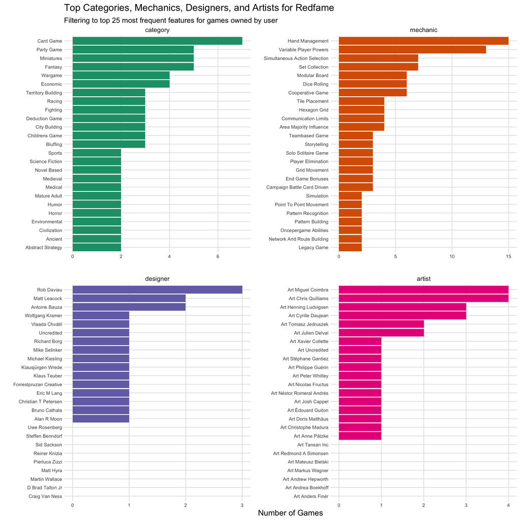

# 2 Modeling **Redfame’s** Collection

| username | dataset | period | games_owned | games_rated | games_played |
| --- | --- | --- | --- | --- | --- |
| Redfame | training | published before 2020 | 24 | 0 | 24 |
| Redfame | test | published 2020 or later | 1 | 0 | 1 |

There are two main (binary) outcomes we will be modeling for the user.

The first, **own** refers to whether the user currently lists a game as owned in their collection. The second, **played** refers to whether the user currently owns, has rated, or previously owned a game. This means the latter will generally have a larger list of games, but may still be a useful category to examine for people who play lots of games without necessarily owning them.

We will train predictive models to learn the probability that the user will own or play individual games based on their features.

## 2.1 Coefficients for Redfame

We can examine coefficients from the trained modes, which are penalized logistic regressions fit to our two main outcomes. Positive values indicate that a feature increases a user’s probabilility of owning/rating a game, while negative values indicate a feature decreases the probability.

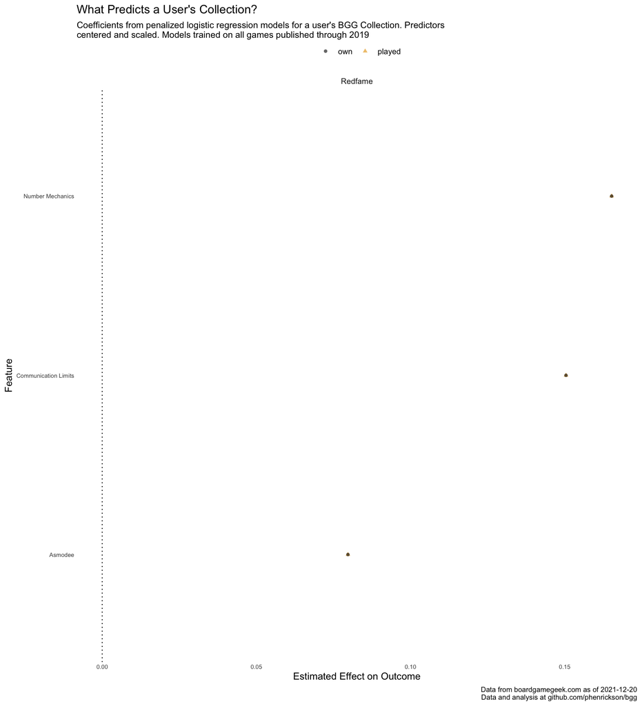

## 2.2 Visualizing Predictors for Redfame’s Collection

Why did the model identify these features? We can make density plots of the important features for predicting whether the user owned a game. Blue indicates the density for games owned by the user, while grey indicates the density for games not owned by the user.

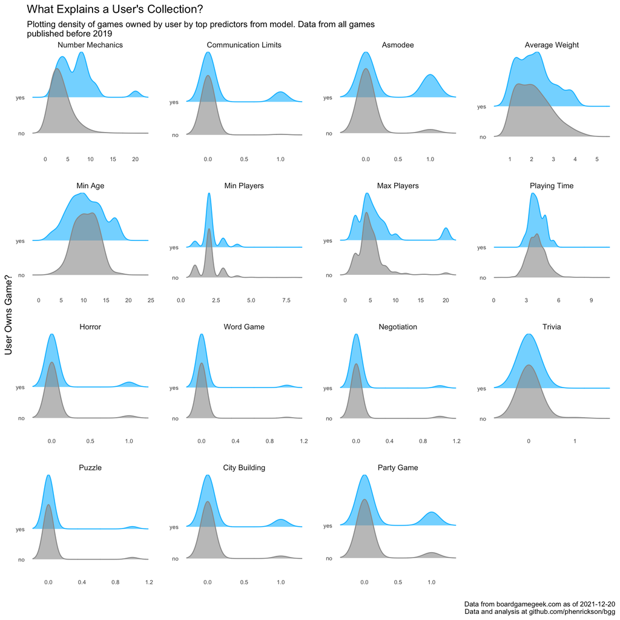

Binary predictors can be difficult to see with this visualization, so we can also directly examine the percentage of games in a user’s collection with a predictor vs the percentage of all games with that predictor.

| username | Feature | % of Games with Feature In_Collection | % of Games with Feature All_Games | Ratio |
| --- | --- | --- | --- | --- |
| Redfame | Communication Limits | 16.7% | 1.0% | 17.4 |
| Redfame | Asmodee | 33.3% | 5.3% | 6.3 |
| Redfame | Racing | 12.5% | 2.8% | 4.5 |
| Redfame | Sports | 8.3% | 2.0% | 4.1 |
| Redfame | Miniatures | 16.7% | 5.3% | 3.1 |
| Redfame | City Building | 12.5% | 4.3% | 2.9 |
| Redfame | Party Game | 20.8% | 8.4% | 2.5 |
| Redfame | Word Game | 4.2% | 1.8% | 2.4 |
| Redfame | Murdermystery | 4.2% | 1.8% | 2.4 |
| Redfame | Childrens Game | 12.5% | 5.6% | 2.2 |
| Redfame | Horror | 8.3% | 4.0% | 2.1 |
| Redfame | Deduction Game | 12.5% | 6.4% | 2.0 |
| Redfame | Trains | 4.2% | 2.2% | 1.9 |
| Redfame | Ancient | 8.3% | 4.5% | 1.8 |
| Redfame | Medieval | 8.3% | 6.3% | 1.3 |
| Redfame | Puzzle | 4.2% | 3.4% | 1.2 |
| Redfame | Negotiation | 4.2% | 3.7% | 1.1 |
| Redfame | Action Dexterity | 4.2% | 4.8% | 0.9 |
| Redfame | Fighting | 8.3% | 9.1% | 0.9 |
| Redfame | Trivia | 0.0% | 1.8% | 0.0 |
| Redfame | Mafia | 0.0% | 0.7% | 0.0 |
| Redfame | Prehistoric | 0.0% | 1.0% | 0.0 |
| Redfame | Realtime | 0.0% | 4.2% | 0.0 |
| Redfame | Memory Game | 0.0% | 1.7% | 0.0 |
| Redfame | World War II | 0.0% | 4.0% | 0.0 |

# 3 Assess Model’s Performance on Training Set

Before predicting games in upcoming years, we can examine how well the model did and what games it liked in the training set. In this case, we used resampling techniques (cross validation) to ensure that the model had not seen a game before making its predictions.

## 3.1 Separation Plot

An easy way to examine the performance of classification model is to view a separation plot. We plot the predicted probabilities from the model for every game (from resampling) from lowest to highest. We then overlay a blue line for any game that the user does own. A good classifier is one that is able to *separate* the blue (games owned by the user) from the white (games not owned by the user), with most of the blue occurring at the highest probabilities (right side of the chart).

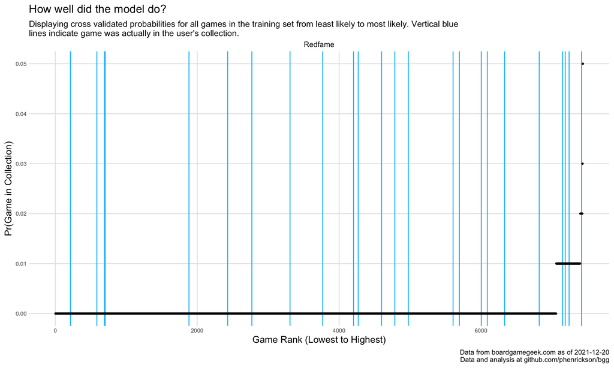

## 3.2 Top Games for **Redfame** from Training Set

We can display this information in table form, displaying the 100 games with the highest probability of ownership, adding a blue line when the user does own the game.

| username | yearpublished | game_id | name | pred_played | pred_own | actual_played | actual_own |
| --- | --- | --- | --- | --- | --- | --- | --- |
| Redfame | 2014 | 164265 | Witness | 0.05 | 0.05 | 0 | 0 |
| Redfame | 1999 | 1353 | Time's Up! | 0.05 | 0.05 | 0 | 0 |
| Redfame | 2019 | 263155 | One Key | 0.05 | 0.05 | 0 | 0 |
| Redfame | 2010 | 98778 | Hanabi | 0.05 | 0.05 | 0 | 0 |
| Redfame | 2018 | 225694 | Decrypto | 0.03 | 0.03 | 0 | 0 |
| Redfame | 2017 | 209778 | Magic Maze | 0.03 | 0.03 | 0 | 0 |
| Redfame | 2016 | 205322 | The Oregon Trail Card Game | 0.03 | 0.03 | 0 | 0 |
| Redfame | 2018 | 205896 | Rising Sun | 0.03 | 0.03 | 0 | 0 |
| Redfame | 2015 | 153999 | ...and then, we held hands. | 0.02 | 0.02 | 0 | 0 |
| Redfame | 2018 | 249821 | Codenames: Harry Potter | 0.02 | 0.02 | 0 | 0 |
| Redfame | 2017 | 218603 | Photosynthesis | 0.02 | 0.02 | 0 | 0 |
| Redfame | 2019 | 270971 | Era: Medieval Age | 0.02 | 0.02 | 0 | 0 |
| Redfame | 2018 | 231327 | The Grizzled: Armistice Edition | 0.02 | 0.02 | 0 | 0 |
| Redfame | 2018 | 258308 | Fuji | 0.02 | 0.02 | 0 | 0 |
| Redfame | 2018 | 258444 | Gingerbread House | 0.02 | 0.02 | 0 | 0 |
| Redfame | 2011 | 148319 | Tragedy Looper | 0.02 | 0.02 | 0 | 0 |
| Redfame | 1988 | 4688 | Angola | 0.02 | 0.02 | 0 | 0 |
| Redfame | 2016 | 168681 | Beyond Baker Street | 0.02 | 0.02 | 0 | 0 |
| Redfame | 2016 | 217353 | Assembly | 0.02 | 0.02 | 0 | 0 |
| Redfame | 2018 | 266445 | Sherlock: Propagation | 0.02 | 0.02 | 0 | 0 |
| Redfame | 2018 | 266446 | Sherlock: Paradero Desconocido | 0.02 | 0.02 | 0 | 0 |
| Redfame | 2006 | 57660 | Time's Up! Edición Azul | 0.02 | 0.02 | 0 | 0 |
| Redfame | 2009 | 46158 | Time's Up! Academy | 0.02 | 0.02 | 0 | 0 |
| Redfame | 2017 | 234396 | Muse | 0.02 | 0.02 | 0 | 0 |
| Redfame | 2014 | 156129 | Deception: Murder in Hong Kong | 0.02 | 0.02 | 0 | 0 |
| Redfame | 2005 | 15062 | Shadows over Camelot | 0.02 | 0.02 | 0 | 0 |
| Redfame | 2015 | 181304 | Mysterium | 0.02 | 0.02 | 1 | 1 |
| Redfame | 2018 | 259374 | Belratti | 0.02 | 0.02 | 0 | 0 |
| Redfame | 2018 | 254640 | Just One | 0.02 | 0.02 | 0 | 0 |
| Redfame | 2010 | 62219 | Dominant Species | 0.02 | 0.02 | 0 | 0 |

[output cut: 70 more lines]

We can also more formally assess how well the model did in resampling by looking at the area under the receiver operating characteristic. A perfect model would receive a score of 1, while a model that cannot predict the outcome will default to a score of 0.5. The extent to which something is a *good* score depends on the setting, but generally anything in the .8 to .9 range is very good while the .7 to .8 range is perfectly acceptable.

| username | outcome_type | .metric | .estimator | .estimate |
| --- | --- | --- | --- | --- |
| Redfame | own | roc_auc | binary | 0.724 |
| Redfame | played | roc_auc | binary | 0.724 |

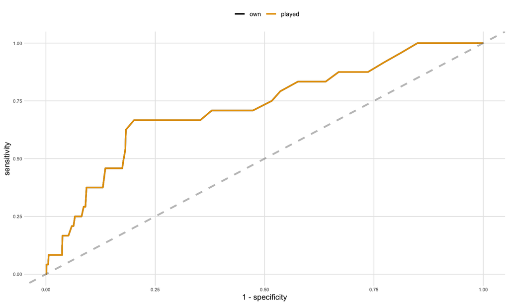

Another way to think about the model performance is to view its lift, or its ability to detect the positive outcomes over that of a null model. High lift indicates the model can much more quickly find all of the positive outcomes (in this case, games owned or played by the user), while a model with no lift is no better than random guessing.

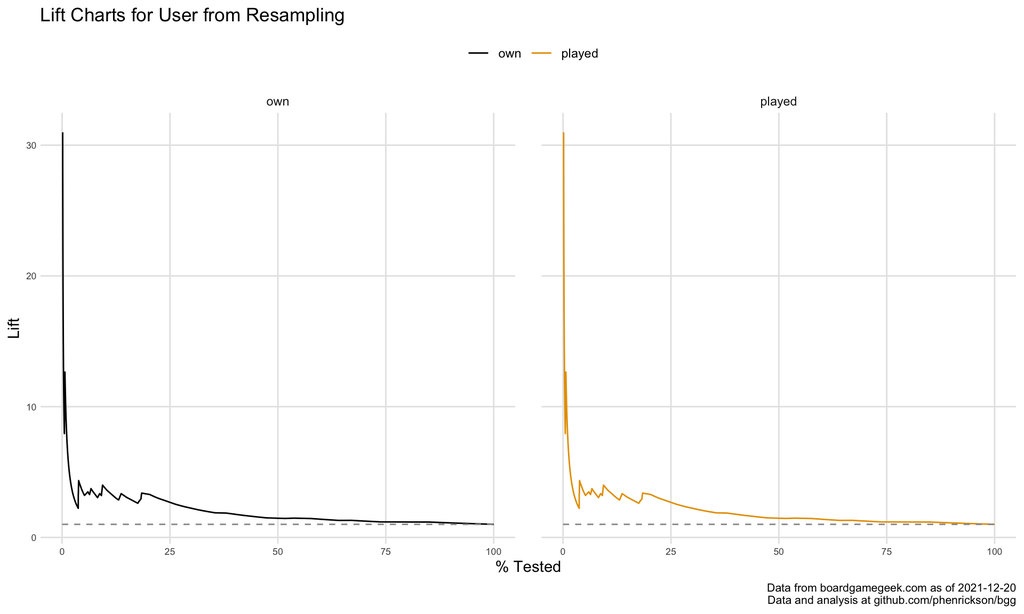

## 3.3 Most and Least Likely Games

What games does the model think Redfame is **most likely to own** that are **not** in their collection?

| username | yearpublished | game_id | name | pred_own | actual_own |
| --- | --- | --- | --- | --- | --- |
| Redfame | 2014 | 164265 | Witness | 0.05 | 0 |
| Redfame | 1999 | 1353 | Time's Up! | 0.05 | 0 |
| Redfame | 2019 | 263155 | One Key | 0.05 | 0 |
| Redfame | 2010 | 98778 | Hanabi | 0.05 | 0 |
| Redfame | 2018 | 225694 | Decrypto | 0.03 | 0 |

What games does the model think Redfame is **least likely to own** that **are** in their collection?

| username | yearpublished | game_id | name | pred_own | actual_own |
| --- | --- | --- | --- | --- | --- |
| Redfame | 2006 | 25417 | BattleLore | 0 | 1 |
| Redfame | 2015 | 173346 | 7 Wonders Duel | 0 | 1 |
| Redfame | 2010 | 67492 | Battles of Westeros | 0 | 1 |
| Redfame | 2017 | 175324 | Fog of Love | 0 | 1 |
| Redfame | 2015 | 161936 | Pandemic Legacy: Season 1 | 0 | 1 |

## 3.4 Top Games by Year

Top 25 games most likely to be owned by the user in each year, highlighting in blue the games that the user has owned/played.

| rank | 2011 | 2012 | 2013 | 2014 | 2015 | 2016 | 2017 | 2018 | 2019 |
| --- | --- | --- | --- | --- | --- | --- | --- | --- | --- |
| 1 | Tragedy Looper | Space Cadets | Bomb Squad | Witness | ...and then, we held hands. | The Oregon Trail Card Game | Magic Maze | Decrypto | One Key |
| 2 | Ascension: Return of the Fallen | Targi | Dungeon Twister: The Card Game | Deception: Murder in Hong Kong | Mysterium | Beyond Baker Street | Photosynthesis | Rising Sun | Era: Medieval Age |
| 3 | Mage Knight Board Game | Suburbia | Prosperity | Akrotiri | The Grizzled | Assembly | Muse | Codenames: Harry Potter | Letter Jam |
| 4 | Takenoko | Tzolk'in: The Mayan Calendar | The Builders: Middle Ages | Patchwork | The Game | Okey Dokey | Mountains of Madness | The Grizzled: Armistice Edition | The Crew: The Quest for Planet Nine |
| 5 | Ascension: Storm of Souls | Serenissima (Second Edition) | Patchistory | Castles of Mad King Ludwig | Burgle Bros. | 13 Days: The Cuban Missile Crisis | Arkham Noir: Case #1 – The Witch Cult Murders | Fuji | Hearts and Minds: Vietnam 1965-1975 (Third Edition) |
| 6 | Dixit: Odyssey | War of the Ring: Second Edition | Koryŏ | Deus | Forbidden Stars | One Deck Dungeon | Heaven & Ale | Gingerbread House | Black Rose Wars |
| 7 | Letters from Whitechapel | Il Vecchio | BANG! The Dice Game | DungeonQuest Revised Edition | Far Space Foundry | Inis | Bunny Kingdom | Sherlock: Propagation | Space Gate Odyssey |
| 8 | Eclipse | Kairo | Timeline: Music & Cinema | Splendor | Copper Country | Yokohama | Whitehall Mystery | Sherlock: Paradero Desconocido | Yukon Airways |
| 9 | Flash Point: Fire Rescue | Santa Cruz | Concept | La Granja | The Bloody Inn | Aventuria: Adventure Card Game | Majesty: For the Realm | Belratti | The Magnificent |
| 10 | Québec | Robinson Crusoe: Adventures on the Cursed Island | Rory's Story Cubes: Prehistoria | ZhanGuo | Mombasa | Hit Z Road | Harvest Dice | Just One | Zona: The Secret of Chernobyl |
| 11 | Band of Brothers: Screaming Eagles | Cardline: Animals | Tajemnicze Domostwo | Alchemists | Barony | Clank!: A Deck-Building Adventure | Gloomhaven | A Song of Ice & Fire: Tabletop Miniatures Game – Stark vs Lannister Starter Set | Star Wars: Outer Rim |
| 12 | A Few Acres of Snow | Libertalia | Cardline: Globetrotter | Outfoxed! | The Builders: Antiquity | Covalence: A Molecule Building Game | Nemo's War (Second Edition) | Duelosaur Island | God of War: The Card Game |
| 13 | Sekigahara: The Unification of Japan | Dixit: Journey | LEADERS: The Combined Strategy Game | Shadows of Malice | Nippon | Imhotep | 878 Vikings: Invasions of England | Kero | Sierra West |
| 14 | Fighting Formations: Grossdeutschland Motorized Infantry Division | Keyflower | Zombicide Season 2: Prison Outbreak | Bucket of Doom | 504 | Pandemic: Reign of Cthulhu | 1754: Conquest – The French and Indian War | Arkham Noir: Case #2 – Called Forth By Thunder | Tiny Epic Mechs |
| 15 | No Retreat! The Russian Front | Bolt Action | Room 25 | HINT | Grand Austria Hotel | 4 Gods | Clans of Caledonia | The Order of Vampire Hunters | Old West Empresario |
| 16 | Nightfighter | Rumble in the Dungeon | Brew Crafters | Spurs: A Tale in the Old West | Unusual Suspects | Dream Home | Dinosaur Island | The Edge: Dawnfall | MegaCity: Oceania |
| 17 | Space Infantry | Terra Mystica | Circus Train (Second Edition) | Xia: Legends of a Drift System | Bang! The Dice Game: The Walking Dead | Islebound | Civilization: A New Dawn | Dice Hospital | Red Outpost |
| 18 | No Peace Without Spain!: The War of the Spanish Succession 1702-1713 | Archipelago | Spyrium | Fallen | Codenames | Match Madness | Sherlock Holmes Consulting Detective: Carlton House & Queen's Park | Dungeon Alliance | Machina Arcana (Second/Third Edition) |
| 19 | FAB: Sicily | Descent: Journeys in the Dark (Second Edition) | Bruxelles 1893 | Holdfast: Russia 1941-42 | Cardline: Marvel | Final Touch | Unstable Unicorns | Fireball Island: The Curse of Vul-Kar | Last Bastion |
| 20 | Revolver | Lords of Waterdeep | Dungeon Command: Blood of Gruumsh | Heroes of Normandie | Zombicide Season 3: Rue Morgue | Citadels | Breaking Bad: The Board Game | Underwater Cities | Yōkai |
| 21 | 1955: The War of Espionage | Kemet | Band of Brothers: Ghost Panzer | Strife: Legacy of the Eternals | Mafia de Cuba | StoryLine: Fairy Tales | Sub Terra | Blackout: Hong Kong | Black Angel |
| 22 | Test of Fire: Bull Run 1861 | Kings of War | BattleLore: Second Edition | Star Wars: Empire vs. Rebellion | Aye, Dark Overlord! The Green Box | Codenames: Pictures | Unlock!: Escape Adventures – The Elite | VOLT | Posthuman Saga |
| 23 | Steam Torpedo: First Contact | Mage Wars Arena | No Retreat!: The North African Front | Fleet Commander: 1 – Ignition | Grimslingers | Codenames: Deep Undercover | Fire of Eidolon | Century: Eastern Wonders | Barrage |
| 24 | Yomi | Dungeon Command: Sting of Lolth | Crusade and Revolution: The Spanish Civil War, 1936-1939 | Jäger und Späher | A Study in Emerald (Second Edition) | Perdition's Mouth: Abyssal Rift | Custom Heroes | Blue Lagoon | Pipeline |
| 25 | Laser Chess | Dungeon Command: Heart of Cormyr | Sedition Wars: Battle for Alabaster | Space Hulk (Fourth Edition) | Stockpile | Kreus | Unlock!: Escape Adventures – Fifth Avenue | Azul: Stained Glass of Sintra | Comanauts |

## 3.5 Interactive Predictions from Resampling

Interactive table for predictions from resampling.

|  | username | yearpublished | rank | game_id | name | pred_played | pred_own | actual_played | actual_own |
| --- | --- | --- | --- | --- | --- | --- | --- | --- | --- |
| 1 | Redfame | 1900 | 280 | 45 | Perudo | 0.01 | 0.01 | 0 | 0 |
| 2 | Redfame | 1900 | 393 | 5546 | Marbles | 0 | 0 | 0 | 0 |
| 3 | Redfame | 1900 | 396 | 11901 | Tic-Tac-Toe | 0 | 0 | 0 | 0 |
| 4 | Redfame | 1900 | 446 | 188 | Go | 0 | 0 | 0 | 0 |
| 5 | Redfame | 1900 | 557 | 171 | Chess | 0 | 0 | 0 | 0 |
| 6 | Redfame | 1900 | 566 | 2065 | Shogi | 0 | 0 | 0 | 0 |
| 7 | Redfame | 1900 | 568 | 2393 | Xiangqi | 0 | 0 | 0 | 0 |
| 8 | Redfame | 1900 | 799 | 26952 | International Checkers | 0 | 0 | 0 | 0 |
| 9 | Redfame | 1900 | 836 | 1602 | The Royal Game of Ur | 0 | 0 | 0 | 0 |
| 10 | Redfame | 1900 | 837 | 2083 | Checkers | 0 | 0 | 0 | 0 |

[output cut: 7426 more lines]

# 4 Validating the Model on 2020

How well did a model trained on a user’s collection through 2019 perform in predicting games for the user from 2020?

| username | outcome_type | yearpublished | .metric | .estimator | .estimate |
| --- | --- | --- | --- | --- | --- |
| Redfame | own | 2020 | roc_auc | binary | 0.667 |
| Redfame | played | 2020 | roc_auc | binary | 0.667 |

Table of top 25 games from 2020, highlighting games that the user owns.

| username | yearpublished | game_id | name | pred_own | pred_played | actual_own | actual_played |
| --- | --- | --- | --- | --- | --- | --- | --- |
| Redfame | 2020 | 291457 | Gloomhaven: Jaws of the Lion | 0.05 | 0.05 | 0 | 0 |
| Redfame | 2020 | 301767 | Mysterium Park | 0.02 | 0.02 | 0 | 0 |
| Redfame | 2020 | 319966 | The King Is Dead: Second Edition | 0.02 | 0.02 | 0 | 0 |
| Redfame | 2020 | 184267 | On Mars | 0.01 | 0.01 | 0 | 0 |
| Redfame | 2020 | 246900 | Eclipse: Second Dawn for the Galaxy | 0.01 | 0.01 | 0 | 0 |
| Redfame | 2020 | 256317 | Guild Master | 0.01 | 0.01 | 0 | 0 |
| Redfame | 2020 | 256940 | Krosmaster: Blast | 0.01 | 0.01 | 0 | 0 |
| Redfame | 2020 | 262274 | D6: Dungeons, Dudes, Dames, Danger, Dice and Dragons! | 0.01 | 0.01 | 0 | 0 |
| Redfame | 2020 | 262939 | Far Away | 0.01 | 0.01 | 0 | 0 |
| Redfame | 2020 | 282922 | Windward | 0.01 | 0.01 | 0 | 0 |
| Redfame | 2020 | 288169 | The Fox in the Forest Duet | 0.01 | 0.01 | 0 | 0 |
| Redfame | 2020 | 288513 | Tranquility | 0.01 | 0.01 | 0 | 0 |
| Redfame | 2020 | 292333 | Cowboys II: Cowboys & Indians Edition | 0.01 | 0.01 | 0 | 0 |
| Redfame | 2020 | 294788 | Conqueror: Final Conquest | 0.01 | 0.01 | 0 | 0 |
| Redfame | 2020 | 295905 | Cosmic Frog | 0.01 | 0.01 | 0 | 0 |
| Redfame | 2020 | 296498 | 10 Dice | 0.01 | 0.01 | 0 | 0 |
| Redfame | 2020 | 296517 | Contact: Signals from Outer Space | 0.01 | 0.01 | 0 | 0 |
| Redfame | 2020 | 297735 | Disciple Detective | 0.01 | 0.01 | 0 | 0 |
| Redfame | 2020 | 299179 | Chancellorsville 1863 | 0.01 | 0.01 | 0 | 0 |
| Redfame | 2020 | 300322 | Hallertau | 0.01 | 0.01 | 0 | 0 |
| Redfame | 2020 | 302193 | Wonder Woman: Challenge of the Amazons | 0.01 | 0.01 | 0 | 0 |
| Redfame | 2020 | 302465 | Obsidia | 0.01 | 0.01 | 0 | 0 |
| Redfame | 2020 | 302723 | Forgotten Waters | 0.01 | 0.01 | 0 | 0 |
| Redfame | 2020 | 302734 | Master Word | 0.01 | 0.01 | 0 | 0 |
| Redfame | 2020 | 306735 | Under Falling Skies | 0.01 | 0.01 | 0 | 0 |

# 5 Predicting Upcoming Games (2020 and On) for **Redfame**

Examine the top games for the test set.

| username | yearpublished | game_id | name | rank | own | played |
| --- | --- | --- | --- | --- | --- | --- |
| Redfame | 2020 | 291457 | Gloomhaven: Jaws of the Lion | 1 | 0.05 | 0.05 |
| Redfame | 2020 | 319966 | The King Is Dead: Second Edition | 2 | 0.02 | 0.02 |
| Redfame | 2020 | 301767 | Mysterium Park | 3 | 0.02 | 0.02 |
| Redfame | 2020 | 310448 | Zombie Teenz Evolution | 4 | 0.01 | 0.01 |
| Redfame | 2020 | 316377 | 7 Wonders (Second Edition) | 5 | 0.01 | 0.01 |
| Redfame | 2020 | 294788 | Conqueror: Final Conquest | 6 | 0.01 | 0.01 |
| Redfame | 2020 | 300322 | Hallertau | 7 | 0.01 | 0.01 |
| Redfame | 2020 | 306735 | Under Falling Skies | 8 | 0.01 | 0.01 |
| Redfame | 2020 | 316750 | The Princess Bride Adventure Book Game | 9 | 0.01 | 0.01 |
| Redfame | 2020 | 326767 | Infinity N4: Core Rules | 10 | 0.01 | 0.01 |
| Redfame | 2020 | 314040 | Pandemic Legacy: Season 0 | 11 | 0.01 | 0.01 |
| Redfame | 2020 | 256940 | Krosmaster: Blast | 12 | 0.01 | 0.01 |
| Redfame | 2020 | 262274 | D6: Dungeons, Dudes, Dames, Danger, Dice and Dragons! | 13 | 0.01 | 0.01 |
| Redfame | 2020 | 282922 | Windward | 14 | 0.01 | 0.01 |
| Redfame | 2020 | 302723 | Forgotten Waters | 15 | 0.01 | 0.01 |
| Redfame | 2020 | 295905 | Cosmic Frog | 16 | 0.01 | 0.01 |
| Redfame | 2020 | 299179 | Chancellorsville 1863 | 17 | 0.01 | 0.01 |
| Redfame | 2020 | 302465 | Obsidia | 18 | 0.01 | 0.01 |
| Redfame | 2020 | 316554 | Dune: Imperium | 19 | 0.01 | 0.01 |
| Redfame | 2020 | 246900 | Eclipse: Second Dawn for the Galaxy | 20 | 0.01 | 0.01 |
| Redfame | 2020 | 308652 | Age of Dogfights: WW1 | 21 | 0.01 | 0.01 |
| Redfame | 2020 | 184267 | On Mars | 22 | 0.01 | 0.01 |
| Redfame | 2020 | 256317 | Guild Master | 23 | 0.01 | 0.01 |
| Redfame | 2020 | 292333 | Cowboys II: Cowboys & Indians Edition | 24 | 0.01 | 0.01 |
| Redfame | 2020 | 296517 | Contact: Signals from Outer Space | 25 | 0.01 | 0.01 |
| Redfame | 2021 | 298102 | Roll Camera!: The Filmmaking Board Game | 1 | 0.03 | 0.03 |
| Redfame | 2021 | 335541 | We Care: a Grizzled Game | 2 | 0.02 | 0.02 |
| Redfame | 2021 | 290236 | Canvas | 3 | 0.01 | 0.01 |
| Redfame | 2021 | 298383 | Golem | 4 | 0.01 | 0.01 |
| Redfame | 2021 | 340466 | Unfathomable | 5 | 0.01 | 0.01 |
| Redfame | 2021 | 259962 | Stress Botics | 6 | 0.01 | 0.01 |
| Redfame | 2021 | 300217 | Merchants of the Dark Road | 7 | 0.01 | 0.01 |
| Redfame | 2021 | 301366 | Caves of Rwenzori | 8 | 0.01 | 0.01 |
| Redfame | 2021 | 340909 | Gloomholdin' | 9 | 0.01 | 0.01 |
| Redfame | 2021 | 273330 | Bloodborne: The Board Game | 10 | 0.01 | 0.01 |
| Redfame | 2021 | 342848 | World of Warcraft: Wrath of the Lich King | 11 | 0.01 | 0.01 |
| Redfame | 2021 | 295785 | Euthia: Torment of Resurrection | 12 | 0.01 | 0.01 |
| Redfame | 2021 | 319263 | One Card Dungeon | 13 | 0.01 | 0.01 |
| Redfame | 2021 | 291859 | Riftforce | 14 | 0.01 | 0.01 |
| Redfame | 2021 | 249277 | Brazil: Imperial | 15 | 0.01 | 0.01 |
| Redfame | 2021 | 251661 | Oathsworn: Into the Deepwood | 16 | 0.01 | 0.01 |
| Redfame | 2021 | 291572 | Oath: Chronicles of Empire and Exile | 17 | 0.01 | 0.01 |
| Redfame | 2021 | 343905 | Boonlake | 18 | 0.01 | 0.01 |
| Redfame | 2021 | 340237 | Wonder Book | 19 | 0.01 | 0.01 |
| Redfame | 2021 | 310873 | Carnegie | 20 | 0.01 | 0.01 |
| Redfame | 2021 | 285967 | Ankh: Gods of Egypt | 21 | 0.01 | 0.01 |
| Redfame | 2021 | 329839 | So Clover! | 22 | 0.01 | 0.01 |
| Redfame | 2021 | 323118 | Crack the Code | 23 | 0.01 | 0.01 |
| Redfame | 2021 | 324856 | The Crew: Mission Deep Sea | 24 | 0.01 | 0.01 |
| Redfame | 2021 | 326804 | Rorschach | 25 | 0.01 | 0.01 |
| Redfame | 2022 | 295770 | Frosthaven | 1 | 0.03 | 0.03 |
| Redfame | 2022 | 256680 | Return to Dark Tower | 2 | 0.01 | 0.01 |
| Redfame | 2022 | 338067 | 6: Siege – The Board Game | 3 | 0.01 | 0.01 |
| Redfame | 2022 | 283137 | Human Punishment: The Beginning | 4 | 0.01 | 0.01 |
| Redfame | 2022 | 273814 | Deliverance | 5 | 0.01 | 0.01 |
| Redfame | 2022 | 317321 | Darkest Dungeon: The Board Game | 6 | 0.01 | 0.01 |
| Redfame | 2022 | 317511 | Tindaya | 7 | 0.01 | 0.01 |
| Redfame | 2022 | 322524 | Bardsung | 8 | 0.01 | 0.01 |
| Redfame | 2022 | 331106 | The Witcher: Old World | 9 | 0.01 | 0.01 |
| Redfame | 2022 | 155250 | TseuQuesT | 10 | 0.00 | 0.00 |
| Redfame | 2022 | 286158 | D.E.I.: Divide et Impera | 11 | 0.00 | 0.00 |
| Redfame | 2022 | 266064 | Trudvang Legends | 12 | 0.00 | 0.00 |
| Redfame | 2022 | 274056 | HEL: The Last Saga | 13 | 0.00 | 0.00 |
| Redfame | 2022 | 322354 | DEFCON 1 | 14 | 0.00 | 0.00 |
| Redfame | 2022 | 253759 | Paint the Roses | 15 | 0.00 | 0.00 |
| Redfame | 2022 | 266592 | TacTiki | 16 | 0.00 | 0.00 |
| Redfame | 2022 | 288080 | Dice Realms | 17 | 0.00 | 0.00 |
| Redfame | 2022 | 328866 | My Father's Work | 18 | 0.00 | 0.00 |
| Redfame | 2022 | 330973 | Volfyirion Guilds | 19 | 0.00 | 0.00 |
| Redfame | 2022 | 260923 | Titan | 20 | 0.00 | 0.00 |
| Redfame | 2022 | 274277 | Jurassic World Miniature Game | 21 | 0.00 | 0.00 |
| Redfame | 2022 | 293941 | Mage Noir | 22 | 0.00 | 0.00 |
| Redfame | 2022 | 312512 | The Transcontinental | 23 | 0.00 | 0.00 |
| Redfame | 2022 | 313807 | Oros | 24 | 0.00 | 0.00 |
| Redfame | 2022 | 315695 | Veiled Fate | 25 | 0.00 | 0.00 |

## 5.1 Interactive Table for Upcoming Games 2020 and On

|  | username | yearpublished | game_id | name | rank | own | played |
| --- | --- | --- | --- | --- | --- | --- | --- |
| 1 | Redfame | 2020 | 291457 | Gloomhaven: Jaws of the Lion | 1 | 0.05 | 0.05 |
| 2 | Redfame | 2021 | 298102 | Roll Camera!: The Filmmaking Board Game | 2 | 0.03 | 0.03 |
| 3 | Redfame | 2022 | 295770 | Frosthaven | 3 | 0.03 | 0.03 |
| 4 | Redfame | 2021 | 335541 | We Care: a Grizzled Game | 4 | 0.02 | 0.02 |
| 5 | Redfame | 2020 | 319966 | The King Is Dead: Second Edition | 5 | 0.02 | 0.02 |
| 6 | Redfame | 2020 | 301767 | Mysterium Park | 6 | 0.02 | 0.02 |
| 7 | Redfame | 2020 | 310448 | Zombie Teenz Evolution | 7 | 0.01 | 0.01 |
| 8 | Redfame | 2020 | 316377 | 7 Wonders (Second Edition) | 8 | 0.01 | 0.01 |
| 9 | Redfame | 2021 | 290236 | Canvas | 9 | 0.01 | 0.01 |
| 10 | Redfame | 2021 | 298383 | Golem | 10 | 0.01 | 0.01 |

[output cut: 1627 more lines]